Copyright © [Jeffrey A. Walker](https://github.com/middleprofessor)

[Back to R doodles](https://rdoodles.rbind.io)

# Models for two (or more) categorical X variables – Factorial designs

Jeffrey A. Walker

11/13/2020

# 1 Models for two (or more) categorical $X$ – Factorial designs

## 1.2 Example 1: Maize defense response

This chapter uses data from an experiment measuring the effect of two defense signals on the defense response in Maize plants. In response to herbivory from insects, maize, and other plants, release multiple, chemical signals into the air (chemicals that evaporate into the air are known as volatile compounds). These chemicals signal the plant, and neighboring plants, to secrete anti-herbivory hormones, including abcisic acid and jasmonic acid. The researchers investigated the effects of two volatile compounts, (Z)‐3‐hexenyl acetate (HAC) and Indole, on the defense response both each without the other and in combination.

The example data come from Figure 1a, which is the effect of HAC and Indole on tissue concentrations of the hormone abcisic acid (ABA). The design is fully crossed with two factors, each with two levels: $hac$, with levels “HAC-” and “HAC+”, and $indole$, with levels (“Indole-” and “Indole+”). A good way to visualize the treatment combinations in a crossed design is with a $m \times p$ table showing all combinations of the $m$ levels of factor 1 ($hac$) against the $p$ levels of factor 2 ($indole$).

|  | HAC- | HAC+ |
| --- | --- | --- |
| Indole- | Control | HAC |
| Indole+ | Indole | HAC+Indole |

### 1.2.1 Analysis

#### 1.2.1.1 Examine the data

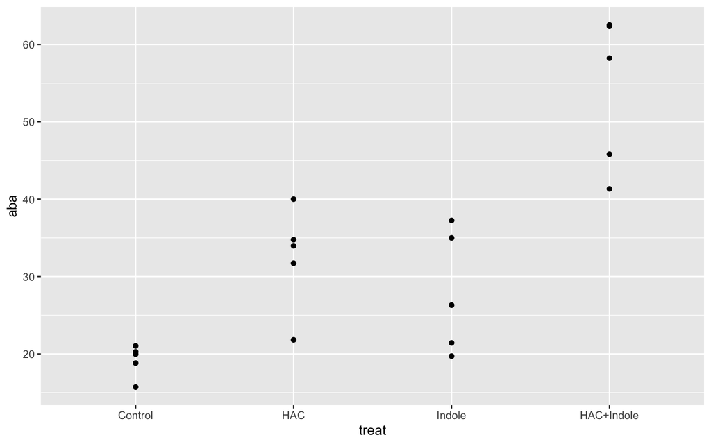

```r
qplot(x = treat, y = aba, data = fig1)
```

Too few points for box plot. control variance is small. No obvious implausible points. fit with lm but recognize small n warning for any inference.

#### 1.2.1.2 Fit the model

```r
m1 <- lm(aba ~ hac * indole, data = fig1)
```

#### 1.2.1.3 Model check

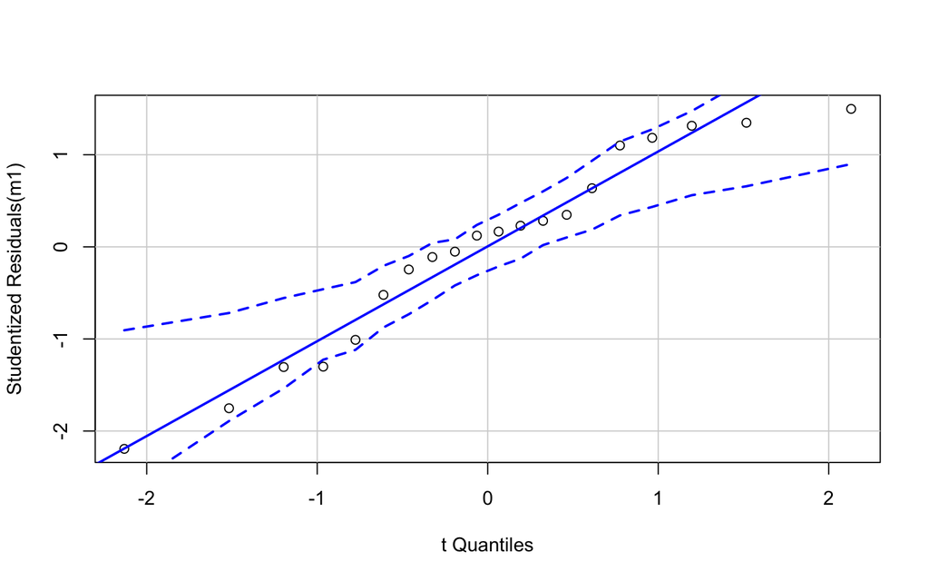

```r
qqPlot(m1, id = FALSE)
```

A plausible sample from a Normal distribution.

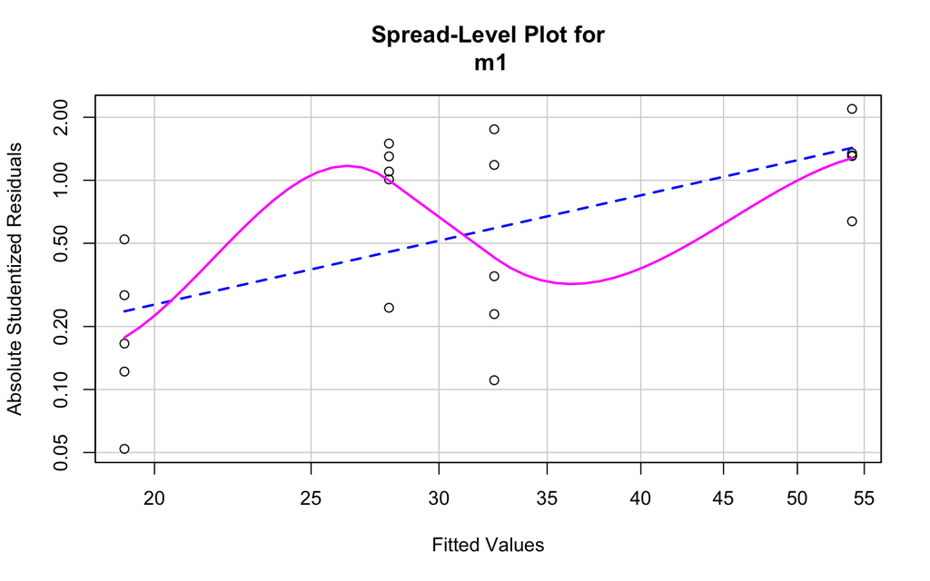

```
##
## Suggested power transformation:  -0.7343415
```

```r
spreadLevelPlot(m1)
```

A bit of increase in variance with mean.

#### 1.2.1.4 Inference from the model

```r
m1_coef <- cbind(coef(summary(m1)),
                 confint(m1))
knitr::kable(m1_coef, digits = 3)
```

|  | Estimate | Std. Error | t value | Pr(>\|t\|) | 2.5 % | 97.5 % |
| --- | --- | --- | --- | --- | --- | --- |
| (Intercept) | 19.160 | 3.227 | 5.938 | 0.000 | 12.320 | 26.001 |
| hacHAC+ | 13.297 | 4.563 | 2.914 | 0.010 | 3.623 | 22.971 |
| indoleIndole+ | 8.776 | 4.563 | 1.923 | 0.072 | -0.898 | 18.450 |
| hacHAC+:indoleIndole+ | 12.818 | 6.454 | 1.986 | 0.064 | -0.863 | 26.499 |

```r
m1_emm <- emmeans(m1, specs = c("hac", "indole"))
knitr::kable(m1_emm, digits = 2)
```

| hac | indole | emmean | SE | df | lower.CL | upper.CL |
| --- | --- | --- | --- | --- | --- | --- |
| HAC- | Indole- | 19.16 | 3.23 | 16 | 12.32 | 26.00 |
| HAC+ | Indole- | 32.46 | 3.23 | 16 | 25.62 | 39.30 |
| HAC- | Indole+ | 27.94 | 3.23 | 16 | 21.10 | 34.78 |
| HAC+ | Indole+ | 54.05 | 3.23 | 16 | 47.21 | 60.89 |

```r
m1_pairs <- contrast(m1_emm,
                     method = "revpairwise",
                     simple = "each",
                     combine = TRUE,
                     adjust = "none") %>%
  summary(infer = TRUE)

knitr::kable(m1_pairs, digits = 2)
```

| indole | hac | contrast | estimate | SE | df | lower.CL | upper.CL | t.ratio | p.value |
| --- | --- | --- | --- | --- | --- | --- | --- | --- | --- |
| Indole- | . | HAC+ - HAC- | 13.30 | 4.56 | 16 | 3.62 | 22.97 | 2.91 | 0.01 |
| Indole+ | . | HAC+ - HAC- | 26.12 | 4.56 | 16 | 16.44 | 35.79 | 5.72 | 0.00 |
| . | HAC- | Indole+ - Indole- | 8.78 | 4.56 | 16 | -0.90 | 18.45 | 1.92 | 0.07 |
| . | HAC+ | Indole+ - Indole- | 21.59 | 4.56 | 16 | 11.92 | 31.27 | 4.73 | 0.00 |

#### 1.2.1.5 Plot the model

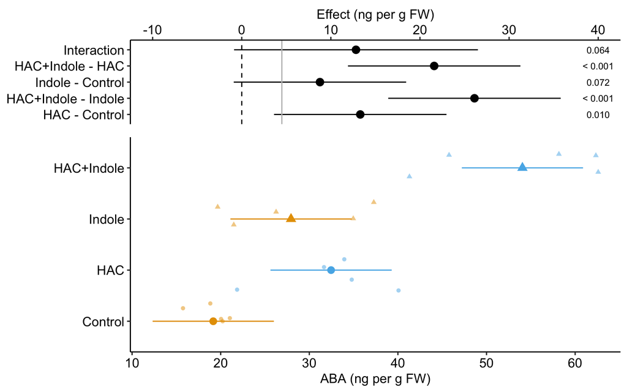

### 1.2.2 A factorial model adds an interaction effect to the coefficients table

A factorial design allows a researcher to estimate the interaction between two factors. An interaction is an effect between two variables in a linear model. The interaction effect is the coefficient $beta_3$ in the linear model

$$\begin{equation}
aba = \beta_0 + \beta_1 hac_{HAC^+} + \beta_2 indole_{Indole^+} + \beta_3 hac_{HAC^+}:indole_{Indole^+} +\varepsilon
\tag{1}
\end{equation}$$

$hac_{HAC^+}$ and $indole_{Indole^+}$ are dummy-coded **indicator variables** indicating group membership. $hac_{HAC^+} : indole_{Indole^+}$ is a dummy-coded variable for the interaction between $hac$ and $indole$. The value of this variable is the product of the two indicator variables in the interaction ($hac_{HAC^+}$ and $indole_{Indole^+}$), which can be verified with the model matrix (which here, is computed from the subset of the data that includeds only the first two rows of each treatment combination)

|  | (Intercept) | hacHAC+ | indoleIndole+ | hacHAC+:indoleIndole+ |
| --- | --- | --- | --- | --- |
| 1 | 1 | 0 | 0 | 0 |
| 2 | 1 | 0 | 0 | 0 |
| 6 | 1 | 1 | 0 | 0 |
| 7 | 1 | 1 | 0 | 0 |
| 11 | 1 | 0 | 1 | 0 |
| 12 | 1 | 0 | 1 | 0 |
| 16 | 1 | 1 | 1 | 1 |
| 17 | 1 | 1 | 1 | 1 |

The coefficient table is

Table 1: Coefficient table of the factorial model

|  | Estimate | Std. Error | t value | Pr(>\|t\|) | 2.5 % | 97.5 % |
| --- | --- | --- | --- | --- | --- | --- |
| (Intercept) | 19.16 | 3.23 | 5.9 | 0.000 | 12.32 | 26.00 |
| hacHAC+ | 13.30 | 4.56 | 2.9 | 0.010 | 3.62 | 22.97 |
| indoleIndole+ | 8.78 | 4.56 | 1.9 | 0.072 | -0.90 | 18.45 |
| hacHAC+:indoleIndole+ | 12.82 | 6.45 | 2.0 | 0.064 | -0.86 | 26.50 |

An interaction is a **non-additive effect**. Think about this. Adding HAC alone increases ABA concentration by 13.3 ng per g FW. Adding Indole alone increases ABA concentration by 8.8 ng per g FW. If these effects were purely additive, then adding both HAC and Indole to the Control mean should result in a mean of 19.2 + 13.3 + 8.8 = 41.3 ng per g FW in the HAC+Indole group. The modeled mean is 54.1 ng per g FW. The difference observed - additive is 54.1 - 41.3 = 12.8 ng per g FW. Compare this to the interaction coefficient in the coefficient table.

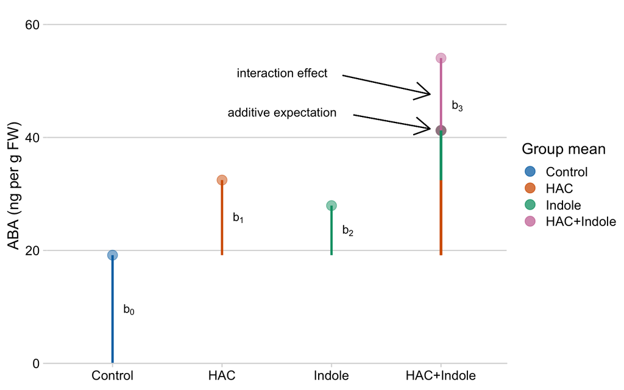

Figure 1: Meaning of coefficients in factorial model  
b0 (blue line) is the mean of the reference (Control). b1 (orange line) is the /HAC effect. Numerically, it is the mean of the HAC group minus the mean of the reference. b2 (green line) is the Indole effect. Numerically it is the mean of the Indole group minus the mean of the reference. The expected mean of the HAC+Indole group if HAC and Indole were additive is b0 + b1 + b2 (gray circle). b3 (purple line) is the interaction effect. Numerically, it is the observed mean of the HAC+Indole group minus the expected additive mean (gray circle)

### 1.2.3 The biological interpretation of an interaction effect

The biological reasons causing interaction effects are highly variable but lets consider how interactions *might* arise in the context of the ABA defense response to HAC and Indole. Additive effects (no interaction) may occur when combined treatments act independently of each other. This might occur in the Maize ABA response if the signaling path from HAC reception to ABA secretion and Indole reception to ABA secretion occur in different cells or by different signaling pathways and activity in either pathway has no influence on the other. Positive, or **synergistic** interaction effects may occur when combined treatments augment each other’s ability to affect the response. This could occur in the Maize ABA response if an active signaling path from one of the volatile compound to ABA secretion makes the signaling path from the other compound to ABA secretion more sensitive to that compound. Negative, or **antagonistic** interaction effects may occur when combined treatments interfere with each other’s ability to affect the response. This could occur in the Maize ABA response if an active signaling path from one of the volatile compound to ABA secretion inhibits the signaling path from the other compound to ABA secretion. Negative interaction effects could also occur if there is a simple threshold response and all it takes is either the HAC or the Indole signaling pathway to activate the response.

### 1.2.4 Conditional and marginal means

Table 2: Conditional (white background) and marginal (color background) means from full factorial model fit to ABA data

|  | HAC- | HAC+ | mean |
| --- | --- | --- | --- |
| Indole- | 19.160 | 32.458 | 25.809 |
| Indole+ | 27.936 | 54.052 | 40.994 |
| mean | 23.548 | 43.255 |  |

The conditional means from model (1) are shown in the upper left $2 \times 2$ block (white background) of Table 2. These means are conditional on the level of $hac$ and $indole$. The values in the last row and column are the **marginal means**, which are the means of the associated row or column cells (these values are in the margins of the table). More generally, *marginal* refers to a statistic averaged across multiple levels of another variable. The marginal means of $indole$ (orange background) are the means of the `Indole+` and `Indole-` rows. The marginal means of $hac$ (blue background) are the means of the `HAC+` and `HAC-` columns.

### 1.2.5 Simple (conditional) effects

In a factorial experiment with crossed A and B factors, there is an effect of factor A (relative to the reference, or another level of factor A) for each of the *p* levels of factor B. And, there is an effect of factor B (relative to the reference, or another level of factor B) for each of the *m* levels of factor A.

For the maize defense response experiment, there is an Indole effect at `hac = HAC-` and a different effect at `hac = HAC+`. Similarly, there is a HAC effect at `indole = Indole-` and a different effect at `indole = Indole+`. These effects, or **contrasts** (differences in modeled means), are called the **simple effects**. I prefer **conditional effects**, since the value of the effect is conditional on the level factor of the other factor.

Table 3: Conditional (or “simple”) effects of the factorial model.

| indole | hac | contrast | estimate | SE | df | t.ratio | p.value |
| --- | --- | --- | --- | --- | --- | --- | --- |
| Indole- | . | HAC+ - HAC- | 13.3 | 4.56 | 16 | 2.9 | 0.01015 |
| Indole+ | . | HAC+ - HAC- | 26.1 | 4.56 | 16 | 5.7 | 0.00003 |
| . | HAC- | Indole+ - Indole- | 8.8 | 4.56 | 16 | 1.9 | 0.07245 |
| . | HAC+ | Indole+ - Indole- | 21.6 | 4.56 | 16 | 4.7 | 0.00023 |

The first two rows are the conditional effects of $hac$ in each of the levels of $Indole$. The last two rows are the conditional effects of $Indole$ in each of the levels of $hac$.

Table 4: Conditonal (“simple”) effects of HAC (orange background) and Indole (blue background) on ABA concentration. The conditional means of each combination of the factor levels are in the cells with the white background. The simple effect is the difference in the means of the associated row or column.

|  | HAC- | HAC+ | simple |
| --- | --- | --- | --- |
| Indole- | 19.160 | 32.458 | 13.297 |
| Indole+ | 27.936 | 54.052 | 26.115 |
| simple | 8.776 | 21.594 |  |

### 1.2.6 Marginal effects

The average of the conditional effects for a factor are the **marginal effects**, or the **main effects** in ANOVA terminology.

Table 5: Marginal effects of HAC (orange) and Indole (blue) on ABA concentration. Simple effects are in grey cells. The conditional means of each combination of the factor levels are in the white cells.

|  | HAC- | HAC+ | simple | marginal |
| --- | --- | --- | --- | --- |
| Indole- | 19.160 | 32.458 | 13.297 |  |
| Indole+ | 27.936 | 54.052 | 26.115 |  |
| simple | 8.776 | 21.594 |  | 15.185 |
| marginal |  |  | 19.706 |  |

Be careful with reporting marginal effects. In this example, the simple effects of HAC are very different for the `Indole-` and `Indole+` treatment levels and the mean of these two effects may not be especially relevant to the question that we are pursuing. If the simple effects of a factor are similar, then it may make more sense to report the marginal effect.

### 1.2.7 The additive model

Marginal effects can be useful for summarizing a general trend, but, like any average, might not be especially meaningful if there is large heterogeneity of the simple effects, which occurs when the interaction effect is large. The maize ABA response is a good example of marginal effects that would be highly misleading to present without further comment.

If an interaction effect is small, then it can be useful to estimate the effects of the two factors as if the interaction were equal to zero.

$$\begin{equation}
aba = \beta_0 + \beta_1 hac_{HAC^+} + \beta_2 indole_{Indole^+} + \varepsilon
\tag{2}
\end{equation}$$

This is a **reduced model** because one of the terms has been removed from the model. This particular reduced model is often referred to as the **additive model**, since it excludes the interaction term, which is a *product* of other terms. In R, this model is

```r
m2 <- lm(aba ~ hac + indole, data = fig1)
```

The model coefficients of the additive model are

Table 6: Model coefficients of additive model.

|  | Estimate | Std. Error | t value | Pr(>\|t\|) | 2.5 % | 97.5 % |
| --- | --- | --- | --- | --- | --- | --- |
| (Intercept) | 15.96 | 3.03 | 5.3 | 0 | 9.57 | 22.34 |
| hacHAC+ | 19.71 | 3.50 | 5.6 | 0 | 12.33 | 27.08 |
| indoleIndole+ | 15.19 | 3.50 | 4.3 | 0 | 7.81 | 22.56 |

The conditional effects of the reduced model are

Table 7: Conditional effects of additive model.

| indole | hac | contrast | estimate | SE | df | lower.CL | upper.CL | t.ratio | p.value |
| --- | --- | --- | --- | --- | --- | --- | --- | --- | --- |
| Indole- | . | HAC+ - HAC- | 19.70629 | 3.5 | 17 | 12.33 | 27.08 | 5.64 | 0.00003 |
| Indole+ | . | HAC+ - HAC- | 19.70629 | 3.5 | 17 | 12.33 | 27.08 | 5.64 | 0.00003 |
| . | HAC- | Indole+ - Indole- | 15.18518 | 3.5 | 17 | 7.81 | 22.56 | 4.34 | 0.00044 |
| . | HAC+ | Indole+ - Indole- | 15.18518 | 3.5 | 17 | 7.81 | 22.56 | 4.34 | 0.00044 |

Compare the table of marginal effects of the additive model to the table of marginal effects of the full model. The estimates are the same but the *t*-values and *p*-values differ because of different degrees of freedom (the full model estimates one more parameter, the interaction effect). The estimate is the same only if the design is balanced, which means that each combination of treatment levels has the same sample size *n*.

### 1.2.8 Reduce models for the right reason

Unless one factor truly has no effect, there will always be an interaction. As stated above, interactions are ubiquitous. If an interaction is small, it can make sense to drop the interaction term and re-fit an additive model to estimate marginal effects in order to present a simplified picture of what is going on, with the recognition that these estimates are smoothing over the heterogenity in conditional (simple) effects that truly exist.

Aided and abetted by statistics textbooks for biologists, there is a long history of researchers dropping an interaction effect because the interaction $p>0.05$. Don’t do this. It doesn’t make any sense.

1. The $p$-value is an arbitrary dichotomization of a continuous variable. Would it make sense to behave differently if the interaction were $p=0.051$ vs. $p=0.049$, given that these two p-values are effectively identical?
2. A $p$-value is not evidence that an effect is zero, or “doesn’t exist”, or even that an effect is “trivially small”. This is because $p$-values are a function of measurement error, sampling error, and sample size, in addition to effect size.

## 1.3 Working in R

### 1.3.1 Plotting linear models with crossed factors

#### 1.3.1.1 Response plot – Sample means and error bars using ggpubr

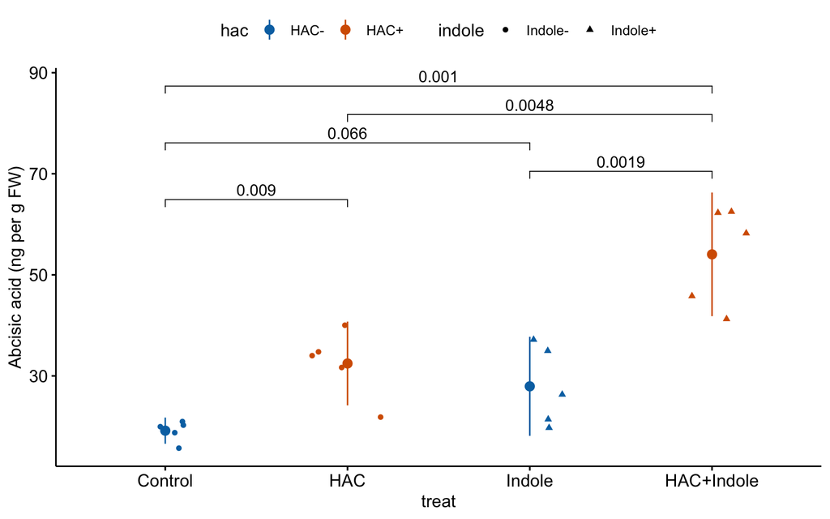

```r
compare_list <- list(c("Control", "HAC"),
                     c("HAC+Indole", "Indole"),
                     c("Control", "Indole"),
                     c("HAC+Indole", "HAC"),
                     c("HAC+Indole", "Control"))
gg1 <- ggstripchart(data = fig1,
                    x = "treat",
                    y = "aba",
                    color = "hac",
                    shape = "indole",
                    add = "mean_ci",
                    ylab = "Abcisic acid (ng per g FW)",
                    palette = pal_ito_seven) +

  stat_compare_means(method = "t.test",
                     comparisons=compare_list)

gg1
```

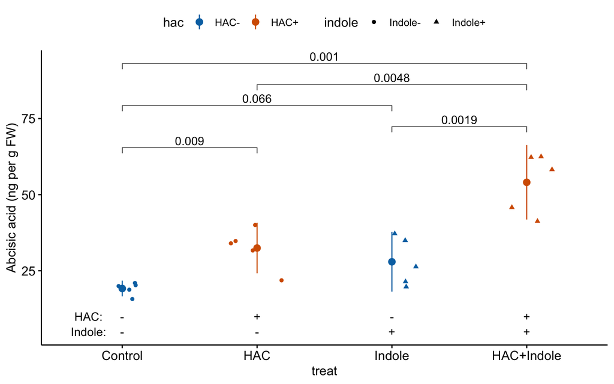

```r
gg2 <- gg1 +
  annotate(geom = "text",
           label = c("-", "+", "-", "+"),
           x = 1:4,
           y = 10
  ) +
  annotate(geom = "text",
           label = c("HAC:"),
           x = 0.75,
           y = 10
  ) +
  annotate(geom = "text",
           label = c("-", "-", "+", "+"),
           x = 1:4,
           y = 5
  ) +
  annotate(geom = "text",
           label = c("Indole:"),
           x = 0.75,
           y = 5
  ) +

    NULL
gg2
```